# MGARCH

Vitalii Rudko

June, 2020

Abstract

This project is extension of the previous one on the VAR model. The first objective of this project is to build and test one of the MGARCH models in R. For that purpose the DCC model was selected. The second objective is to learn how to interpret the particular results at every stage. The last objective is to determine whether there is any relationship between S&P500 daily returns and returns of two big tech companies, namely Microsoft and Apple. Note, the last project on VAR model was built using monthly returns, it was changed for daily, because there was a weak dependence between variables.

# 1 Preparing time series for analysis

I am starting with uploading necessary packages. Notice the package “yahooquotes” is a custom package for importing and exporting data. The package “vars” serves for the model building and testing. Package “MTS” was used for estimating multivariate Ljung-Box statistics. “aTSA” enabled to conduct ADF tests. Package “forecast” improves a little bit existing functions, “acf”, “pcf” and “ccf”. Package “roll” adds the functions for estimation of rolling statistics. Packages “rugarch” and “rmgarch” developed for building univariate and multivariate GARCH models respectively. The last package “ggplot2” is a popular tool for visualization of data.

```r
# Importing packages.
library(yahooquotes)
# Custom package

library(roll)
#Documentation: https://cran.r-project.org/web/packages/roll/roll.pdf

library(vars)
#Documentation: https://cran.r-project.org/web/packages/vars/vars.pdf

library(forecast)
#Documentation: https://cran.r-project.org/web/packages/forecast/forecast.pdf

library(MTS)
#Documentation:  https://www.rdocumentation.org/packages/MTS/versions/1.0

library(aTSA)
#Documentation: https://www.rdocumentation.org/packages/aTSA/versions/3.1.2

library(rugarch)
# Documentation: https://cran.r-project.org/web/packages/rugarch/rugarch.pdf

library(rmgarch)
# Documentation: https://cran.r-project.org/web/packages/rmgarch/rmgarch.pdf

library(ggplot2)
#Documentation: https://cran.r-project.org/web/packages/ggplot2/ggplot2.pdf
```

```r
# Importing data.
tickers <-c("^GSPC","MSFT","AAPL")

data <- yahoo_quotes(tickers,
                     origin = '2010-01-01',
                     today = "2020-01-02"
                     )

names(data) <- c("Date","SP500","MSFT","AAPL")

#Full names:
#SP500 - S&P500
#MSFT - Microsoft Inc.
#AAPL - Apple Inc.
```

Since we are working with the daily data, we can use log returns without fear of loosing accuracy.

```r
# Calculating returns.
data$r_SP500 <- c(NA, diff(log(data$SP500)) )
data$r_MSFT <- c(NA, diff(log(data$MSFT)) )
data$r_AAPL <- c(NA, diff(log(data$AAPL)) )
```

```r
#Creating time series.
SP500 <- ts(data$r_SP500[-1],
            start = 2010,
            end = 2020,
            frequency = 365)

MSFT <-  ts(data$r_MSFT[-1],
            start = 2010,
            end = 2020,
            frequency = 365)

AAPL <-  ts(data$r_AAPL[-1],
            start = 2010,
            end = 2020,
            frequency = 365)

whole <- cbind(SP500, MSFT, AAPL)
```

# 2 Preliminary analysis of the data

Figure 2.1 presents daily quotes of &P500, Microsoft and Apple. As we can see, Microsoft is somewhat more correlated with S&P500 than Apple. In general, Microsoft seems to be a safer investment.

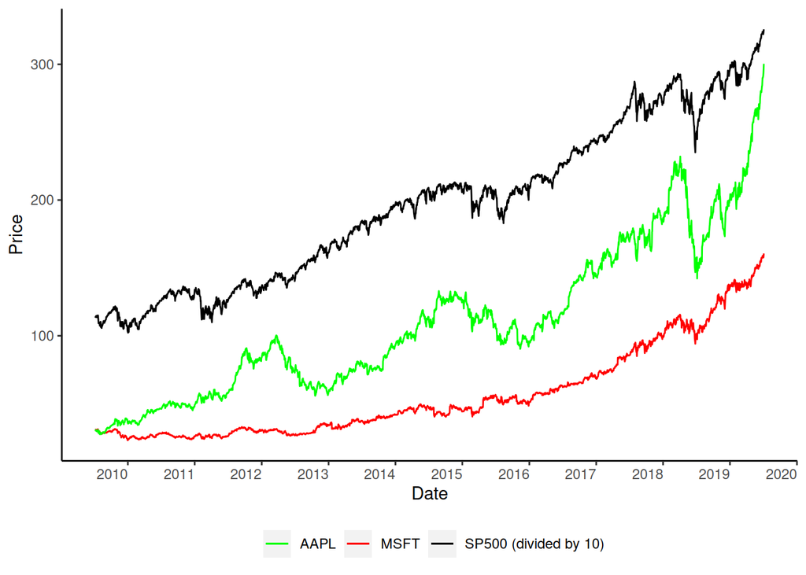

Figure 2.1: S&P500, Microsoft and Apple stock prices.

```r
#Ploting quotes.
ggplot(data)+
  geom_line(aes(x = as.Date(Date), y = SP500/10, color = "SP500 (divided by 10)"))+
  geom_line(aes(x = as.Date(Date), y = MSFT, color = "MSFT"))+
  geom_line(aes(x = as.Date(Date), y = AAPL, color = "AAPL"))+
  labs(x = "Date", y = "Price")+
  scale_x_date(date_breaks = "12 month", date_labels =  "%Y")+
  theme(axis.text.x=element_text(angle=0, hjust=1),
        panel.grid.major = element_blank(),
        panel.grid.minor = element_blank(),
        panel.background = element_blank(),
        axis.line = element_line(colour = "black"),
        legend.position="bottom")+
   scale_color_manual(name = "",
                      values = c(
                        'SP500 (divided by 10)' = 'black',
                        'MSFT' = 'red',
                        'AAPL' = 'green'))
```

The plot of returns in Figure 2.2 suggests that all the processes are stationary. Also, it is obvious that S&P500 is the least volatile and Apple the most.

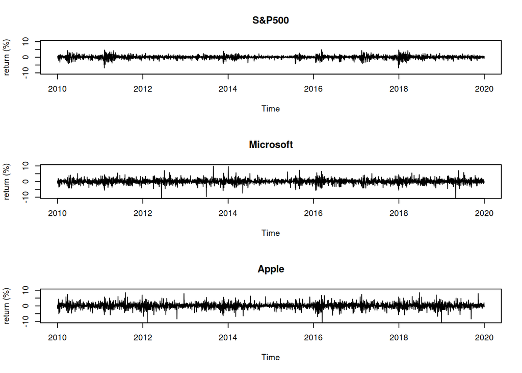

Figure 2.2: Daily returns.

```r
#Plotting returns.
par(mfcol=c(3, 1))
plot(SP500*100, ylab = "return (%)", main ="S&P500", ylim = c(-10,10))
plot(MSFT*100, ylab = "return (%)", main ="Microsoft", ylim = c(-10,10))
plot(AAPL*100, ylab = "return (%)", main ="Apple", ylim = c(-10,10))
```

Current cross-correlations in Figure 2.3 look strong. The cross correlation matrix is shown below the figure.

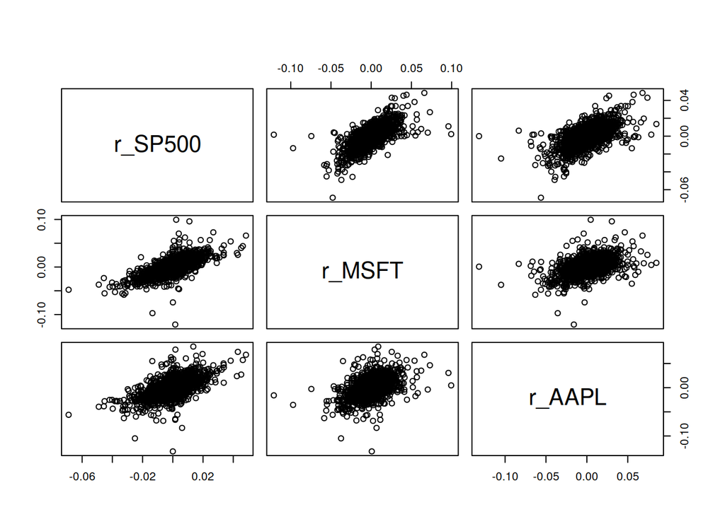

Figure 2.3: Current cross-correlations.

```r
#Current CCM graphical.
pairs(~ r_SP500 + r_MSFT + r_AAPL, data = data, main = NA)
```

```r
#Current CCM numerical
cor(whole)
```

```
##           SP500      MSFT      AAPL
## SP500 1.0000000 0.6774671 0.5720657
## MSFT  0.6774671 1.0000000 0.4195209
## AAPL  0.5720657 0.4195209 1.0000000
```

Lagged cross-correlations are displayed in Figure 2.4. As we see, S&P500 and Apple are correlated with themselves and Microsoft is not. Interesting that some past values of S&P500 depends on the past values of Microsoft. Reverse is true for Apple’s values, they are dependent on both S&P500 and Microsoft values.

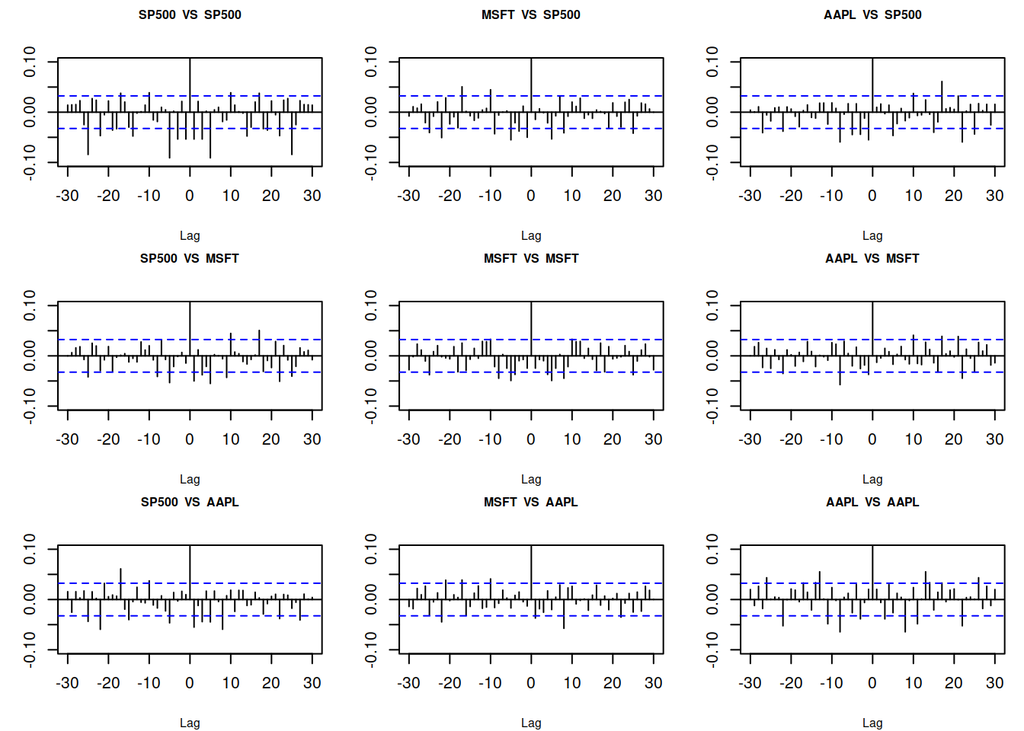

Figure 2.4: Lagged cross-correlations.

```r
#Plotting CCFs.
n <- dim(whole)

par(mfcol=c(n[2], n[2]), cex.main = 0.75, cex.lab = 0.75, mar = c(4,3,3,1))

for( i in 1:n[2]){
  for( j in 1:n[2]){
  p <-  Ccf(whole[, i], whole[, j], plot = FALSE, lag.max = 30)

  main <- labels(whole)
  main <- main[[2]]

  plot(p, main = paste(main[i], " VS ", main[j]), ylab = "CCF", ylim = c(-0.1,0.1))
  }
}
```

Univariate and multivariate tests reject H0, thus the data is lag-correlated, at maximum lag 30.

```r
#Univariate Ljung-Box tests for S&P 500.
print(Box.test(SP500, lag = 30, type = "Ljung-Box"))
```

```
##
##  Box-Ljung test
##
## data:  SP500
## X-squared = 135.77, df = 30, p-value = 2.109e-15
```

```r
print(Box.test(MSFT, lag = 30, type = "Ljung-Box"))
```

```
##
##  Box-Ljung test
##
## data:  MSFT
## X-squared = 62.058, df = 30, p-value = 0.0005151
```

```r
print(Box.test(AAPL, lag = 30, type = "Ljung-Box"))
```

```
##
##  Box-Ljung test
##
## data:  AAPL
## X-squared = 86.515, df = 30, p-value = 2.194e-07
```

```r
#Multivariate Ljung-Box statistics.
mq2(whole, lag = 15)
```

```
## Ljung-Box Statistics:
##         m       Q(m)     df    p-value
##  [1,]   1.0      36.6     9.0        0
##  [2,]   2.0      45.4    18.0        0
##  [3,]   3.0      82.0    27.0        0
##  [4,]   4.0      98.3    36.0        0
##  [5,]   5.0     135.5    45.0        0
##  [6,]   6.0     151.4    54.0        0
##  [7,]   7.0     166.2    63.0        0
##  [8,]   8.0     198.1    72.0        0
##  [9,]   9.0     212.4    81.0        0
## [10,]  10.0     225.7    90.0        0
## [11,]  11.0     245.9    99.0        0
## [12,]  12.0     265.5   108.0        0
## [13,]  13.0     284.2   117.0        0
## [14,]  14.0     319.1   126.0        0
## [15,]  15.0     329.6   135.0        0
```

The ADF tests confirm, that the processes are stationary as was assumed.

```r
#ADF test for SP500.
adf.test(SP500)
```

```
## Augmented Dickey-Fuller Test
## alternative: stationary
##
## Type 1: no drift no trend
##       lag   ADF p.value
##  [1,]   0 -63.6    0.01
##  [2,]   1 -42.9    0.01
##  [3,]   2 -36.7    0.01
##  [4,]   3 -31.4    0.01
##  [5,]   4 -30.4    0.01
##  [6,]   5 -27.3    0.01
##  [7,]   6 -24.5    0.01
##  [8,]   7 -23.2    0.01
##  [9,]   8 -22.0    0.01
## Type 2: with drift no trend
```

[output cut: 23 more lines]

```r
#ADF test for MSFT.
adf.test(MSFT)
```

```
## Augmented Dickey-Fuller Test
## alternative: stationary
##
## Type 1: no drift no trend
##       lag   ADF p.value
##  [1,]   0 -61.8    0.01
##  [2,]   1 -43.5    0.01
##  [3,]   2 -35.6    0.01
##  [4,]   3 -31.8    0.01
##  [5,]   4 -29.5    0.01
##  [6,]   5 -27.2    0.01
##  [7,]   6 -24.8    0.01
##  [8,]   7 -24.0    0.01
##  [9,]   8 -22.9    0.01
## Type 2: with drift no trend
```

[output cut: 23 more lines]

```r
#ADF test for AAPL.
adf.test(AAPL)
```

```
## Augmented Dickey-Fuller Test
## alternative: stationary
##
## Type 1: no drift no trend
##       lag   ADF p.value
##  [1,]   0 -59.0    0.01
##  [2,]   1 -42.3    0.01
##  [3,]   2 -35.9    0.01
##  [4,]   3 -29.8    0.01
##  [5,]   4 -27.4    0.01
##  [6,]   5 -24.5    0.01
##  [7,]   6 -22.5    0.01
##  [8,]   7 -22.5    0.01
##  [9,]   8 -20.9    0.01
## Type 2: with drift no trend
```

[output cut: 23 more lines]

# 3 VAR model selection and checking

The “vars” package helps to choose the appropriate specification of a model by checking four criteria, namely AIC, HQ, SC(BIC) and FPE. AIC criterion tends to choose models with higher order, comparing to HQ and SC. The simpler model is preferred, thus we choose the order of 1.

```r
info_whole <- VARselect(whole, lag.max = 20, type = "const")
info_whole$selection
```

```
## AIC(n)  HQ(n)  SC(n) FPE(n)
##     19      1      1     19
```

Now, we can build the model. The sum of the characteristic roots is less than 1, so the process is stationary. Unfortunately, not all parameters are statistically significant, the fit is still not good and residuals are correlated. This also means, that the poorly fitted mean model may lead to a low forecasting capacity of the MGARCH model. The correlation of the residuals is studied broader in the following steps.

```r
#Building the VAR(1) model.
VAR_1 <- vars::VAR(whole, p = 1, type = "const", season = NULL, exog = NULL)

summary(VAR_1)
```

```
##
## VAR Estimation Results:
## =========================
## Endogenous variables: SP500, MSFT, AAPL
## Deterministic variables: const
## Sample size: 3650
## Log Likelihood: 33751.667
## Roots of the characteristic polynomial:
## 0.04487 0.04487 0.04397
## Call:
## vars::VAR(y = whole, p = 1, type = "const", exogen = NULL)
##
##
## Estimation results for equation SP500:
## ======================================
## SP500 = SP500.l1 + MSFT.l1 + AAPL.l1 + const
##
##            Estimate Std. Error t value Pr(>|t|)
## SP500.l1 -0.0177297  0.0249051  -0.712  0.47658
## MSFT.l1  -0.0156368  0.0151827  -1.030  0.30312
## AAPL.l1  -0.0204415  0.0117549  -1.739  0.08212 .
## const     0.0004758  0.0001596   2.981  0.00289 **
## ---
## Signif. codes:  0 '***' 0.001 '**' 0.01 '*' 0.05 '.' 0.1 ' ' 1
##
##
## Residual standard error: 0.009624 on 3646 degrees of freedom
## Multiple R-Squared: 0.004034,    Adjusted R-squared: 0.003214
## F-statistic: 4.922 on 3 and 3646 DF,  p-value: 0.002054
##
##
## Estimation results for equation MSFT:
## =====================================
## MSFT = SP500.l1 + MSFT.l1 + AAPL.l1 + const
##
##            Estimate Std. Error t value Pr(>|t|)
## SP500.l1  0.0387717  0.0369550   1.049   0.2942
## MSFT.l1  -0.0248160  0.0225285  -1.102   0.2707
## AAPL.l1  -0.0358381  0.0174422  -2.055   0.0400 *
## const     0.0005623  0.0002368   2.375   0.0176 *
```

[output cut: 24 more lines]

```
## F-statistic: 1.423 on 3 and 3646 DF,  p-value: 0.2341
##
##
##
## Covariance matrix of residuals:
##           SP500      MSFT      AAPL
## SP500 9.263e-05 9.309e-05 9.143e-05
## MSFT  9.309e-05 2.039e-04 9.934e-05
## AAPL  9.143e-05 9.934e-05 2.738e-04
##
## Correlation matrix of residuals:
##        SP500   MSFT   AAPL
## SP500 1.0000 0.6773 0.5741
## MSFT  0.6773 1.0000 0.4204
## AAPL  0.5741 0.4204 1.0000
```

```r
# Serial test.
VAR_1.serial <- serial.test(VAR_1, lags.pt = 10, type = "PT.asymptotic")
```

In Figures 3.1, 3.2, 3.3 are presented graphical analysis of residuals for every equation. As we see, the residuals are not normally distributed. Also, all squared residuals are correlated at some point.

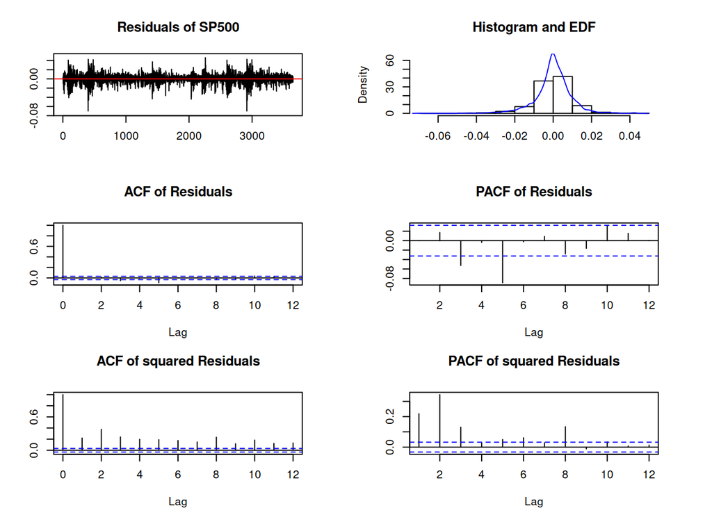

Figure 3.1: Graphical analysis of SP500 residuals.

```r
# Graphical analysis of residuals for SP500.
plot(VAR_1.serial,
     names = "SP500",
     mar=c(4,4,4,4),
     ylim.hist = c(0,65),
     ylim.resid = c(-0.075,0.05),
     xlab.acf = "Lag")
```

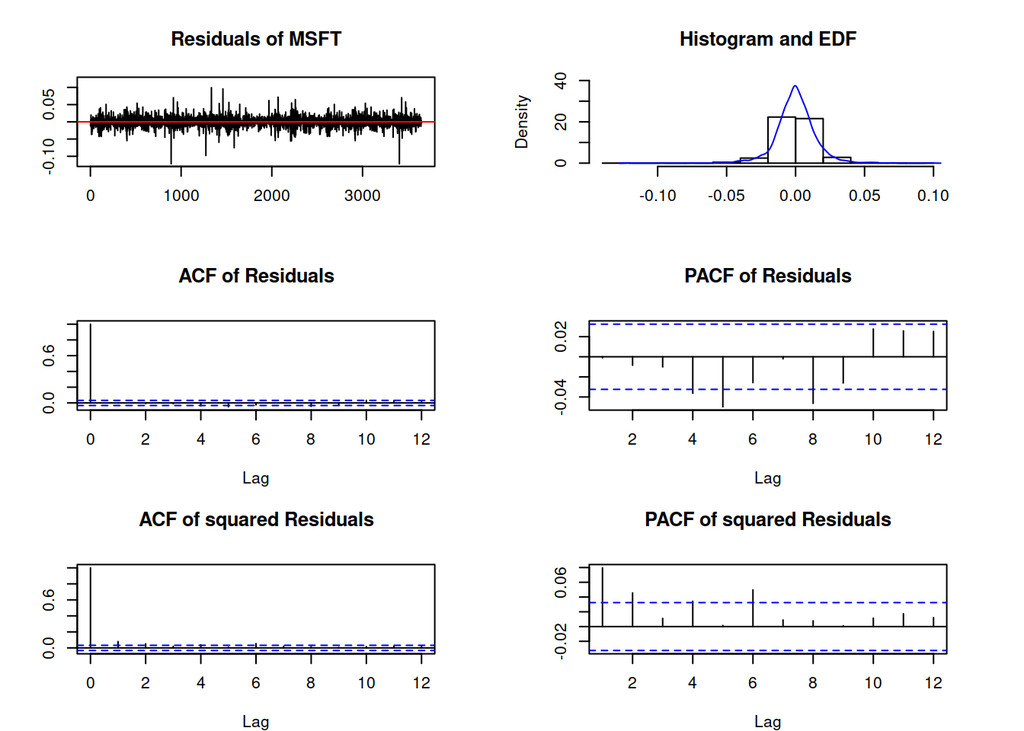

Figure 3.2: Graphical analysis of MSFT residuals.

```r
# Graphical analysis of residuals for MSFT.
plot(VAR_1.serial,
     names = "MSFT",
     mar=c(4,4,4,4),
     ylim.hist = c(0,40),
     ylim.resid = c(-0.12,0.12),
     xlab.acf = "Lag")
```

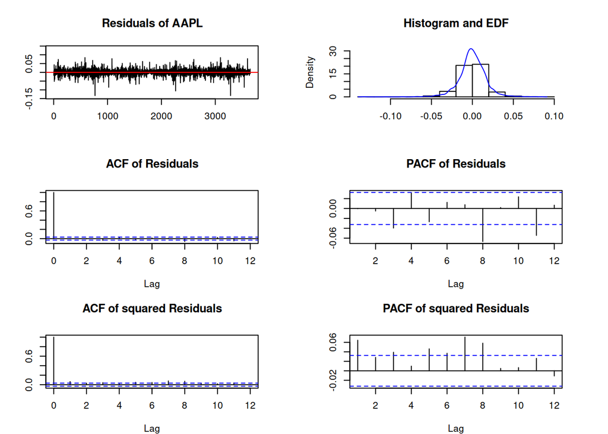

Figure 3.3: Graphical analysis of AAPL residuals.

```r
# Graphical analysis of residuals for AAPL.
plot(VAR_1.serial,
     names = "AAPL",
     mar=c(4,4,4,4),
     ylim.hist = c(0,32),
     ylim.resid = c(-0.14,0.14),
     xlab.acf = "Lag")
```

Additional tests confirm previous assumptions. Ljung-Box test rejects H0, residuals are correlated. Jarque-Bera does not showed normality, so we have to consider t-distribution.

```r
# Testing serial correlation of residuals.
VAR_1.res <- ts(residuals(VAR_1),
                    start = 2010,
                    end = 2020,
                    frequency = 365)

mq2(VAR_1.res, lag = 15)
```

```
## Ljung-Box Statistics:
##            m       Q(m)      df    p-value
##  [1,]   1.0000    0.0118   9.0000     1.00
##  [2,]   2.0000    7.7718  18.0000     0.98
##  [3,]   3.0000   44.6412  27.0000     0.02
##  [4,]   4.0000   59.8474  36.0000     0.01
##  [5,]   5.0000   96.7995  45.0000     0.00
##  [6,]   6.0000  111.3988  54.0000     0.00
##  [7,]   7.0000  124.2524  63.0000     0.00
##  [8,]   8.0000  155.5693  72.0000     0.00
##  [9,]   9.0000  169.2706  81.0000     0.00
## [10,]  10.0000  181.7146  90.0000     0.00
## [11,]  11.0000  202.5406  99.0000     0.00
## [12,]  12.0000  220.1443 108.0000     0.00
## [13,]  13.0000  238.5336 117.0000     0.00
## [14,]  14.0000  274.9552 126.0000     0.00
## [15,]  15.0000  285.6906 135.0000     0.00
```

```r
# Normality test.
VAR_1.norm <- normality.test(VAR_1, multivariate.only = TRUE)
VAR_1.norm
```

```
## $JB
##
##  JB-Test (multivariate)
##
## data:  Residuals of VAR object VAR_1
## Chi-squared = 64204, df = 6, p-value < 2.2e-16
##
##
## $Skewness
##
##  Skewness only (multivariate)
##
## data:  Residuals of VAR object VAR_1
## Chi-squared = 379.69, df = 3, p-value < 2.2e-16
##
##
## $Kurtosis
##
##  Kurtosis only (multivariate)
##
## data:  Residuals of VAR object VAR_1
## Chi-squared = 63825, df = 3, p-value < 2.2e-16
```

There is an ARCH effect, so we have to consider the q order greater than zero for our DCC model.

```r
#ARCH test.
VAR_1.arch <- vars::arch.test(VAR_1, lags.multi = 10, multivariate.only = TRUE)
VAR_1.arch
```

```
##
##  ARCH (multivariate)
##
## data:  Residuals of VAR object VAR_1
## Chi-squared = 1777, df = 360, p-value < 2.2e-16
```

# 4 Exponentially weighted estimate

The exponentially weighted moving-average (EWMA) method can be applied for constracting a smooth covariance matrix, which can be used, according to Tsay (2016), as a banchmark for our future model. Since I did not find any package that would provide that type of function, I had to use a code provided as an appendix for one of the textbooks by Ruppert and Matteson (2015), the source is given inside the code. The first function estimates lambda, and the last one estimates the covariance matrix. In the two subsequent chunks those estimations are performed using innovations from the VAR(1) model and calculated lambda. Note, the function is hidden, in order to see the source code please visit the web page provided.

```r
#SOURCE: "Additional R functions for: Statistics and Data Analysis for Financial
#         Engineering, 2nd Edition" by Ruppert and Matteson.
#         Link: https://people.orie.cornell.edu/davidr/SDAFE2/Rscripts/SDAFE2.R

# Estimating lambda for EWMA function.
VAR_1.lambda <- est.ewma(lambda.0 = 0.95, innov = VAR_1.res)
```

```r
# Estimating EWMA.
VAR_1.sigma  <- sigma.ewma(lambda = VAR_1.lambda$lambda.hat, innov = VAR_1.res)
```

# 5 The DCC model

According to Caporin and Michael McAleer (2013), DCC model does not yield conditional correlations directly, therefore it must be treated with a greater caution. According to the same source its properties poorly described, and basically the model is not derived, but rather stated. Also, it is assumed that all the conditional correlations have the same dynamics. In general, the author suggests to use DCC as a filter not as a model. However, in this study, I will assume, that DCC can be used as a model, and that it is able to produce sensible results .

The model is based on the decomposition of the conditional variance matrix, and the variances are allowed to estimated separetly. It means, we can use different specifications of the univariate GARCH models. Since we have correlated standard errors it is justified to use q order greater than zero, so I choose a standard (1,1) GARCH model. Its mean follows ARMA(1,0) process, since our VAR model is of the first order. That specifications are chosen for all three assets.

```r
# Estimating DCC model.
garch11.spec <- ugarchspec(mean.model = list(armaOrder = c(1,0)),
                          variance.model = list(garchOrder = c(1,1),
                          model = "sGARCH"),
                          distribution.model = "std")

dcc.garch11.spec <- dccspec(uspec = multispec( replicate(3, garch11.spec) ),
                           VAR = TRUE,
                           lag.max = 1,
                           lag.criterion = "HQ",
                           dccOrder = c(1,1),
                           distribution = "mvt")


dcc.fit <- dccfit(dcc.garch11.spec, data = whole)
dcc.fit
```

```
##
## *---------------------------------*
## *          DCC GARCH Fit          *
## *---------------------------------*
##
## Distribution         :  mvt
## Model                :  DCC(1,1)
## No. Parameters       :  30
## [VAR GARCH DCC UncQ] : [12+12+3+3]
## No. Series           :  3
## No. Obs.             :  3651
## Log-Likelihood       :  35203.76
## Av.Log-Likelihood    :  9.64
##
## Optimal Parameters
## -----------------------------------
##                 Estimate  Std. Error  t value Pr(>|t|)
## [SP500].omega   0.000002    0.000002   1.5697 0.116476
## [SP500].alpha1  0.153526    0.030501   5.0335 0.000000
## [SP500].beta1   0.832443    0.028108  29.6159 0.000000
## [SP500].shape   5.014990    0.459236  10.9203 0.000000
## [MSFT].omega    0.000007    0.000001   7.7256 0.000000
## [MSFT].alpha1   0.067382    0.004865  13.8491 0.000000
## [MSFT].beta1    0.900014    0.008042 111.9118 0.000000
## [MSFT].shape    4.388628    0.317359  13.8286 0.000000
## [AAPL].omega    0.000016    0.000005   2.9222 0.003476
## [AAPL].alpha1   0.092023    0.023118   3.9806 0.000069
## [AAPL].beta1    0.855573    0.016763  51.0387 0.000000
## [AAPL].shape    4.576312    0.446514  10.2490 0.000000
## [Joint]dcca1    0.048539    0.016784   2.8919 0.003829
## [Joint]dccb1    0.900925    0.045639  19.7402 0.000000
## [Joint]mshape   4.697374    0.143188  32.8056 0.000000
##
## Information Criteria
## ---------------------
##
## Akaike       -19.268
## Bayes        -19.217
## Shibata      -19.268
## Hannan-Quinn -19.250
##
##
## Elapsed time : 8.492506
```

```r
dcc.fit@model[["modeldata"]][["index"]] <- dcc.fit@model[["modeldata"]][["index"]]  + (40*365+13)*24*60*60
```

The rolling standard deviations and correlations will serve as the second benchmark for our model. The results in Figure 5.1 and Figure 5.2 generally show the good fit.

```r
# Calculating rolling standard deviations.
SP500_sd_roll <- roll_sd(SP500, width = 20)
MSFT_sd_roll <- roll_sd(MSFT, width = 20)
AAPL_sd_roll <- roll_sd(AAPL, width = 20)

dates <- as.Date(c(1:3651), origin = "2010-01-01")
```

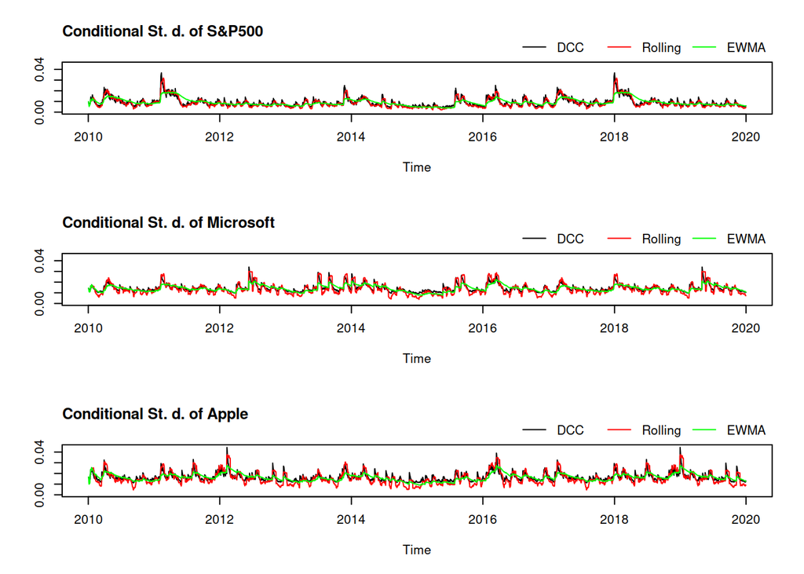

Figure 5.1: DCC vs Rolling vs EWMA conditional standard deviations.

```r
# Plotting conditional standard deviations.
con.cov <-rcov(dcc.fit)

con.std.SP500  <- con.cov[1,1,]^.5
con.std.MSFT   <- con.cov[2,2,]^.5
con.std.AAPL   <- con.cov[3,3,]^.5

par(mfrow = c(3,1))

plot(x = dates,
     y = con.std.SP500,
     type = "l",
     ylab = NA,
     xlab = "Time",
     ylim = c(0, 0.045))
     title("Conditional St. d. of S&P500", adj = 0)
lines(x = dates,
      y = SP500_sd_roll,
      col = 'red' )
lines(x = dates,
      y = VAR_1.sigma[1,1,]^.5,
      col = "green")
legend("bottomright", c("DCC", "Rolling", "EWMA"), lty=c(1,1),
       col = c("black", "red", "green"),
       inset=c(0,1), xpd=TRUE, horiz=TRUE, bty="n"
       )

plot(x = dates,
     y = con.std.MSFT,
     type = "l",
     ylab = NA,
     xlab = "Time",
     ylim = c(0, 0.045))
     title("Conditional St. d. of Microsoft", adj = 0)
lines(x = dates,
      y = MSFT_sd_roll,
      col = 'red' )
lines(x = dates,
      y = VAR_1.sigma[2,2,]^.5,
      col = "green")
legend("bottomright", c("DCC", "Rolling", "EWMA"), lty=c(1,1),
       col = c("black", "red", "green"),
       inset=c(0,1), xpd=TRUE, horiz=TRUE, bty="n"
       )

plot(x = dates,
     y = con.std.AAPL,
     type = "l",
     ylab = NA,
     xlab = "Time",
     ylim = c(0, 0.045))
     title("Conditional St. d. of Apple", adj =0)
lines(x = dates,
      y = AAPL_sd_roll,
      col = 'red' )
lines(x = dates,
      y = VAR_1.sigma[3,3,]^.5,
      col = "green")
legend("bottomright", c("DCC", "Rolling", "EWMA"), lty=c(1,1),
       col = c("black", "red", "green"),
       inset=c(0,1), xpd=TRUE, horiz=TRUE, bty="n"
       )
```

```r
# Calculating rolling standard deviations.
SP500_cor_roll <- roll_cor(SP500, MSFT, width = 20)
MSFT_cor_roll <- roll_cor(SP500, AAPL, width = 20)
AAPL_cor_roll <- roll_cor(MSFT, AAPL, width = 20)
```

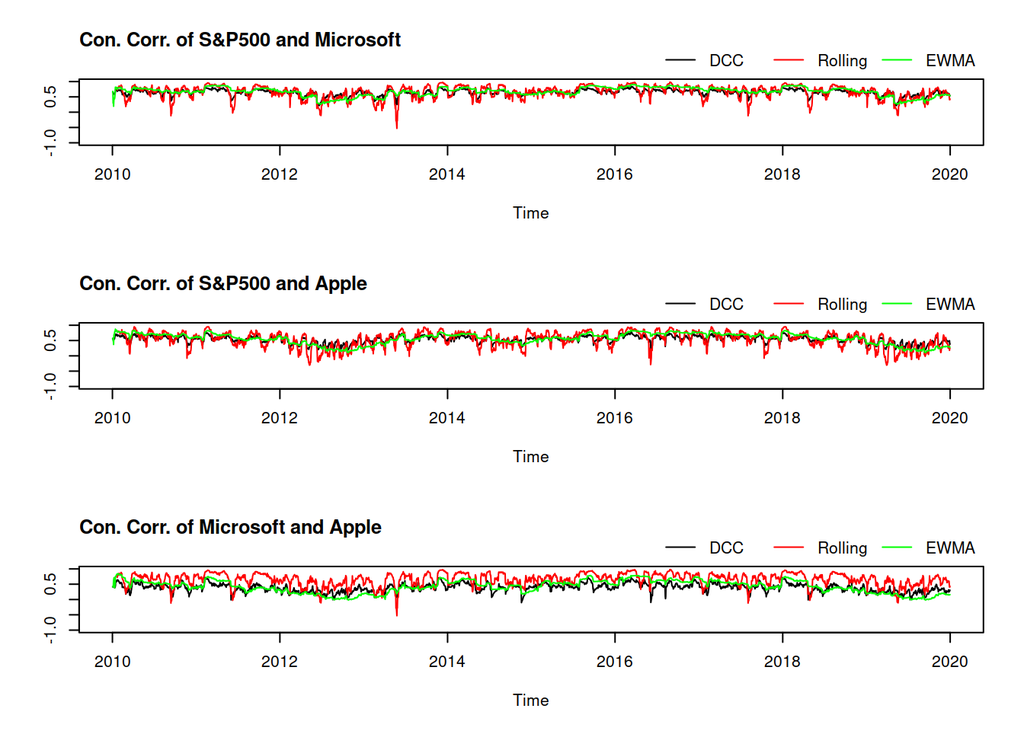

Figure 5.2: DCC vs Rolling vs EWMA conditional correlations.

```r
# Plotting conditional correlations.
con.cor <-rcor(dcc.fit)

con.cor.SP500  <- con.cor[1,2,]
con.cor.MSFT   <- con.cor[1,3,]
con.cor.AAPL   <- con.cor[2,3,]

par(mfrow = c(3,1))

plot(x = dates,
     y = con.cor.SP500,
     type = "l",
     ylab = NA,
     xlab = "Time",
     ylim = c(-1, 1))
     title("Con. Corr. of S&P500 and Microsoft", adj = 0)
lines(x = dates,
      y = SP500_cor_roll,
      col = 'red' )
lines(x = dates,
      y = VAR_1.sigma[2,1,]/sqrt(VAR_1.sigma[1,1,]* VAR_1.sigma[2,2,]),
      col = 'green' )
legend("bottomright", c("DCC", "Rolling", "EWMA"), lty=c(1,1),
       col = c("black", "red", "green"),
       inset=c(0,1), xpd=TRUE, horiz=TRUE, bty="n"
       )

plot(x = dates,
     y = con.cor.MSFT,
     type = "l",
     ylab = NA,
     xlab = "Time",
     ylim = c(-1, 1))
     title("Con. Corr. of S&P500 and Apple", adj = 0)
lines(x = dates,
      y = MSFT_cor_roll,
      col = 'red' )
lines(x = dates,
      y = VAR_1.sigma[3,1,]/sqrt(VAR_1.sigma[1,1,]* VAR_1.sigma[3,3,]),
      col = 'green' )
legend("bottomright", c("DCC", "Rolling", "EWMA"), lty=c(1,1),
       col = c("black", "red", "green"),
       inset=c(0,1), xpd=TRUE, horiz=TRUE, bty="n"
       )

plot(x = dates,
     y = con.cor.AAPL,
     type = "l",
     ylab = NA,
     xlab = "Time",
     ylim = c(-1, 1))
     title("Con. Corr. of Microsoft and Apple", adj = 0)
lines(x = dates,
      y = SP500_cor_roll,
      col = 'red' )
lines(x = dates,
      y = VAR_1.sigma[3,2,]/sqrt(VAR_1.sigma[2,2,]* VAR_1.sigma[3,3,]),
      col = "green")
legend("bottomright", c("DCC", "Rolling", "EWMA"), lty=c(1,1),
       col = c("black", "red", "green"),
       inset=c(0,1), xpd=TRUE, horiz=TRUE, bty="n"
       )
```

# 6 Results of forecasting

Unfortunately, the plot method provided by the “rmgarch” package does not work correctly. Therefore only values are presented.

```r
# Forecasting.
dcc.fcst <- dccforecast(dcc.fit, n.ahead = 5)
dcc.fcst
```

```
##
## *---------------------------------*
## *       DCC GARCH Forecast        *
## *---------------------------------*
##
## Distribution         :  mvt
## Model                :  DCC(1,1)
## Horizon              :  5
## Roll Steps           :  0
## -----------------------------------
##
## 0-roll forecast:
## , , 1
##
##        [,1]   [,2]   [,3]
## [1,] 1.0000 0.5263 0.4038
## [2,] 0.5263 1.0000 0.3102
## [3,] 0.4038 0.3102 1.0000
##
## , , 2
##
##        [,1]   [,2]   [,3]
## [1,] 1.0000 0.5318 0.4106
## [2,] 0.5318 1.0000 0.3139
## [3,] 0.4106 0.3139 1.0000
##
## , , 3
##
##        [,1]   [,2]   [,3]
## [1,] 1.0000 0.5371 0.4170
## [2,] 0.5371 1.0000 0.3175
## [3,] 0.4170 0.3175 1.0000
##
## , , 4
##
##        [,1]   [,2]   [,3]
## [1,] 1.0000 0.5422 0.4231
## [2,] 0.5422 1.0000 0.3208
## [3,] 0.4231 0.3208 1.0000
##
## , , 5
##
##        [,1]   [,2]   [,3]
## [1,] 1.0000 0.5469 0.4288
## [2,] 0.5469 1.0000 0.3240
## [3,] 0.4288 0.3240 1.0000
```

```r
# Show standard deviations.
sigma(dcc.fcst)
```

```
## , , 2020-01-03 01:00:00
##
##           SP500       MSFT       AAPL
## T+1 0.005766069 0.01025439 0.01257605
## T+2 0.005937632 0.01044438 0.01287548
## T+3 0.006102068 0.01062494 0.01315293
## T+4 0.006259969 0.01079674 0.01341055
## T+5 0.006411848 0.01096037 0.01365018
```

# 7 Conclusions

The following conclusions can be drawn from the study:

1. Apple is more volatile than Microsoft, which makes it the riskier investment.
2. The companies and the index are cross-correlated on average in around 50% of cases.
3. The forecasting capacity of a MGARCH model relies on the goodness-of-fit of the assumed mean model. It is possible to compensate the bad fit by choosing appropriate $q$ and $\beta$ orders for GARCH models and the DCC model respectively.
4. Even if the model seems to be well fitted, it is still should be treated with a great caution in terms of forecasting, as in practice some of underlying assumptions may not be fulfilled.
5. As an alternative, the BEKK model should be considered for derivation of conditional correlations, as it is more consistent according to Caporin and Michael McAleer (2013).

# References

Caporin, Massimiliano, and Michael McAleer. 2013. “Ten Things You Should Know About the Dynamic Conditional Correlation Representation.” *Econometrics* 1 (1): 115–26. https://doi.org/10.3390/econometrics1010115.

Ruppert, David, and David S. Matteson. 2015. *Statistics and Data Analysis for Financial Engineering*. Springer Texts in Statistics. New York, NY: Springer New York. https://doi.org/10.1007/978-1-4939-2614-5.

Tsay, Ruey S. 2016. *Analysis of Financial Time Series*. Wiley Series in Probability and Statistics. Sahibabad, In: Wiley India. https://doi.org/10.1002/9780470644560.